# R Markdown

## Visualising The Data

- The next step might be to visualise the data using a boxplot
- Start a new chunk with ```{r boxplot-data}

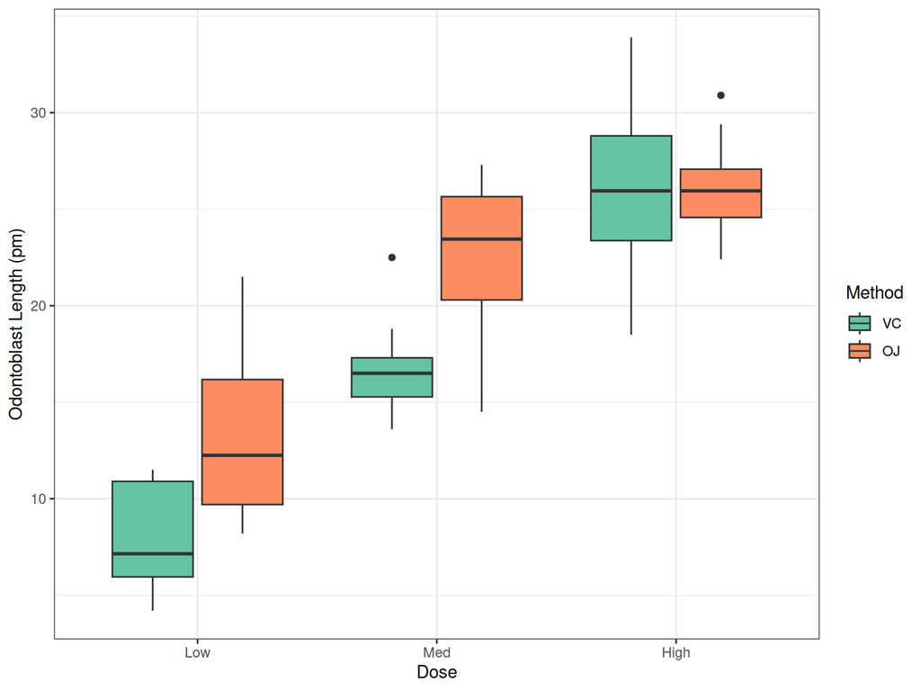

```r
pigs |>
    ggplot(aes(dose, len, fill = supp)) +
    geom_boxplot() +
    labs(
        x = "Dose",
        y = "Odontoblast Length (pm)",
        fill = "Method"
    ) +
    scale_fill_brewer(palette = "Set2") +
    theme_bw()
```

## Visualising the Data

- Type a description of the figure in the `fig.cap` section of the chunk header
  - This will need to be placed inside quotation marks

## Summarising Data

- Next we might like to summarise the data as a table
  - Show group means & standard deviations
- Add the following to a new chunk called `data-summary`
  - I’ve used the HTML code for $\pm$ (&#177;)

```r
pigs |>
    summarise(
        n = n(),
        mn_len = mean(len),
        sd_len = sd(len),
        .by = c(supp, dose)
    ) |>
    mutate(
        mn_len = round(mn_len, 2),
        sd_len = round(sd_len, 2),
        len = paste0(mn_len, " &#177;", sd_len)
    ) |>
    dplyr::select(supp, dose, n, len)
```

```
# A tibble: 6 × 4
  supp  dose      n len
  <fct> <fct> <int> <chr>
1 VC    Low      10 7.98 &#177;2.75
2 VC    Med      10 16.77 &#177;2.52
3 VC    High     10 26.14 &#177;4.8
4 OJ    Low      10 13.23 &#177;4.46
5 OJ    Med      10 22.7 &#177;3.91
6 OJ    High     10 26.06 &#177;2.66
```

## Summarising Data

- This has given a tibble output
- We can produce an HTML table using `pander`

Add the following to your `load-packages` chunk

```r
library(pander)
```

## Producing Tables

```r
pigs |>
    summarise(
        n = n(),
        mn_len = mean(len),
        sd_len = sd(len),
        .by = c(supp, dose)
    ) |>
    mutate(
        mn_len = round(mn_len, 2),
        sd_len = round(sd_len, 2),
        len = paste0(mn_len, " &#177;", sd_len)
    ) |>
    dplyr::select(supp, dose, n, len) |>
    rename_with(str_to_title) |>
    pander(
        justify = "llrr",
        caption = "Odontoblast length for each group shown as mean&#177;SD"
    )
```

Odontoblast length for each group shown as mean±SD

| Supp | Dose | N | Len |
| --- | --- | --- | --- |
| VC | Low | 10 | 7.98 ±2.75 |
| VC | Med | 10 | 16.77 ±2.52 |
| VC | High | 10 | 26.14 ±4.8 |
| OJ | Low | 10 | 13.23 ±4.46 |
| OJ | Med | 10 | 22.7 ±3.91 |
| OJ | High | 10 | 26.06 ±2.66 |

## Analysing Data

- The default output from `lm()` doesn’t look great

```r
lm(len ~ supp + dose + supp:dose, data = pigs) |>
    summary()
```

```
Call:
lm(formula = len ~ supp + dose + supp:dose, data = pigs)

Residuals:
   Min     1Q Median     3Q    Max
 -8.20  -2.72  -0.27   2.65   8.27

Coefficients:
                Estimate Std. Error t value Pr(>|t|)
(Intercept)        7.980      1.148   6.949 4.98e-09 ***
suppOJ             5.250      1.624   3.233  0.00209 **
doseMed            8.790      1.624   5.413 1.46e-06 ***
doseHigh          18.160      1.624  11.182 1.13e-15 ***
suppOJ:doseMed     0.680      2.297   0.296  0.76831
suppOJ:doseHigh   -5.330      2.297  -2.321  0.02411 *
---
Signif. codes:  0 '***' 0.001 '**' 0.01 '*' 0.05 '.' 0.1 ' ' 1

Residual standard error: 3.631 on 54 degrees of freedom
Multiple R-squared:  0.7937,    Adjusted R-squared:  0.7746
F-statistic: 41.56 on 5 and 54 DF,  p-value: < 2.2e-16
```

## Analysing Data

- `pander` can again be used to ‘tidy up’ the output from `lm`

```r
lm(len ~ supp + dose + supp:dose, data = pigs) |>
    summary() |>
    pander(add.significance.stars = TRUE)
```

## Analysing Data

|  | Estimate | Std. Error | t value | Pr(>\|t\|) |  |
| --- | --- | --- | --- | --- | --- |
| **(Intercept)** | 7.98 | 1.148 | 6.949 | 4.984e-09 | * * * |
| **suppOJ** | 5.25 | 1.624 | 3.233 | 0.002092 | * * |
| **doseMed** | 8.79 | 1.624 | 5.413 | 1.463e-06 | * * * |
| **doseHigh** | 18.16 | 1.624 | 11.18 | 1.131e-15 | * * * |
| **suppOJ:doseMed** | 0.68 | 2.297 | 0.2961 | 0.7683 |  |
| **suppOJ:doseHigh** | -5.33 | 2.297 | -2.321 | 0.02411 | * |

Fitting linear model: len ~ supp + dose + supp:dose

| Observations | Residual Std. Error | $R^2$ | Adjusted $R^2$ |
| --- | --- | --- | --- |
| 60 | 3.631 | 0.7937 | 0.7746 |

Interpretation:

- At Low Dose, OJ increases length by 5.25 above VC
- Both Med & High increase length for VC
- The difference in length for OJ is the same for Med as for Low
- The gains for length by OJ are completely lost at High Dose

## Creating Summary Tables

- Multiple other packages exist for table creation
  - All do some things brilliantly, none does everything
- `pander` is a good all-rounder
  - Tables are very simplistic
  - Also enables easy in-line results
- `knitr::kable()` is another good all-rounder
  - Can be nicely tailored using `kableExtra`

## Creating Summary Tables

- To use other packages, $\implies$ `broom::tidy()`
  - Will convert `lm()` output to a `tibble`
  - This can be passed to other packages which make HTML / $\LaTeX$ tables

```r
lm(len ~ supp + dose + supp:dose, data = pigs) |>
    broom::tidy()
```

```
# A tibble: 6 × 5
  term            estimate std.error statistic  p.value
  <chr>              <dbl>     <dbl>     <dbl>    <dbl>
1 (Intercept)        7.98       1.15     6.95  4.98e- 9
2 suppOJ             5.25       1.62     3.23  2.09e- 3
3 doseMed            8.79       1.62     5.41  1.46e- 6
4 doseHigh          18.2        1.62    11.2   1.13e-15
5 suppOJ:doseMed     0.680      2.30     0.296 7.68e- 1
6 suppOJ:doseHigh   -5.33       2.30    -2.32  2.41e- 2
```

## Creating Summary Tables

- `reactable` creates amazing looking HTML tables
  - Incredibly customisable
- `DT` also creates fantastic HTML tables
  - Less flexible with formatting
  - Allows simple downloading to `csv`, `xls` etc.
- `gt` is popular with some
- `xtable` is excellent for $\LaTeX$ output

## Creating Summary Tables

- Many of us really care how the output looks
- I spend huge amounts of time getting this just right

```r
library(reactable)
lm(len ~ supp + dose + supp:dose, data = pigs) |>
  broom::tidy() |>
  mutate(
    term = term |>
      str_replace_all("supp", "Supp = ") |>
      str_replace_all("dose", "Dose = ") |>
      str_replace_all(":", " & ")
  ) |>
  rename_with(str_to_title) |>
  reactable(
    sortable = TRUE, filterable = TRUE,
    defaultColDef = colDef(format = colFormat(digits = 3)),
    theme = reactableTheme(style = list(fontSize = 16)),
    columns = list(
      P.value = colDef(
        name = "P-value",
        cell = \(value) {
          fmt <- ifelse(value > 0.01, "%.3f", "%.2e")
          sprintf(fmt, value)
        }
      )
    )
  )
```

| Term | Estimate | Std.error | Statistic | P-value |
| --- | --- | --- | --- | --- |
| (Intercept) | 7.97999999999998 | 1.14835308804166 | 6.94908219701716 | 4.98419939163386e-09 |
| Supp = OJ | 5.25000000000001 | 1.62401651150154 | 3.23272575298261 | 0.00209246982879016 |
| Dose = Med | 8.79000000000002 | 1.62401651150154 | 5.41250654642231 | 1.46293144787882e-06 |
| Dose = High | 18.16 | 1.62401651150154 | 11.1821523188884 | 1.13067681037436e-15 |
| Supp = OJ & Dose = Med | 0.679999999999991 | 2.29670617608332 | 0.296076183832808 | 0.768307565366804 |
| Supp = OJ & Dose = High | -5.33000000000001 | 2.29670617608332 | -2.32071479386602 | 0.0241082566043808 |

## Complete the Analysis

- After you’re happy with the way your analysis looks
  - A good habit is to finish with a section called `Session Info`
  - Add a code chunk which calls the *R* command `sessionInfo()`
  - Or even `sessionInfo() |> pander()`
- So far we’ve been compiling everything as HTML, but let’s switch to an MS Word document. We could email this to our collaborators, or upload to Google docs
- NB: HTML tables don’t work so well in MSWord $\implies$ stick with `pander`?

# Closing Comments

## Summary

This basic process is incredibly useful

- We never need to cut & paste anything between R and other documents
- Every piece of information comes directly from our *R* analysis
- We can very easily incorporate new data as it arrives
- Source data is **never modified**
- Creates *reproducible research*
- Highly compatible with collaborative analysis & version control (Git)

I learned using R scripts but now I only use these in formal packages, or if defining functions to use across multiple analyses

## A Challenge

Return to the `penguins` dataset and perform a complete RMarkdown analysis. We’ll perform a ‘health-check’ on the penguins and want to monitor their average weight every year. Hopefully our testing will reveal no changes in weight

1. Prepare a summary table of average penguin weights for each species & sex
2. Visualise their weights by year and sex however you think is best
3. Perform an analysis of their weights, including sex and species as you think is appropriate